# GLP1

Here you can see the medication used according to NHS. This results in 23198 prescriptions for 997 people.

```bash
#in bash
grep -E 'Byetta|Ozempic|Wegovy|Bydureon|Trulicty|Lixumia|Victoza|Rybelsus|Liraglutide|Dulaglutide|Exenatide|Lixisenatide|Semaglutide' gp_scripts.txt >glpfile.txt
```

We match on sex, DOB, and BMI at baseline and display characteristics of population before and after matching.

```r
source("~/multistate2/code/utils.R")
prs_subset=readRDS("~/Library/CloudStorage/Dropbox-Personal/pheno_dir/prs_subset.rds")
#glp1=fread("~/Library/CloudStorage/Dropbox-Personal//glp1s.txt")

glp1=fread("~/Library/CloudStorage/Dropbox-Personal//glp1s_withi.txt")
colnames(glp1)[1]=c("Identifier")
colnames(glp1)[3]=c("event_dt")
df_baseline=readRDS("~/Library/CloudStorage/Dropbox-Personal/pheno_dir/output/dfukb_baseline.rds")
glp1$event_dt <- as.Date(glp1$event_dt, format="%d/%m/%Y")
unique_patients <- glp1 %>%
  group_by(Identifier) %>%
  summarize(script_date = min(event_dt))

m=merge(prs_subset,unique_patients,by = "Identifier",all.x = T)
m2=merge(m,df_baseline,by.x = "Identifier",by.y="identifier")

m2$treat=as.integer(ifelse(!is.na(m2$script_date),1,0))
library(MatchIt)

biomarkers=readRDS("~/Library/CloudStorage/Dropbox-Personal/ukbb-ehr-data/data/biomarkers.rds")
bmi=biomarkers[biomarkers$variable%in%"bmi",]
bmi$date <- as.Date(bmi$date, format="%Y/%m/%d")
sorted_data <- bmi %>%
  arrange(eid, date) %>%
  group_by(eid)  %>%
  slice(n())


names(sorted_data)=c("eid","date_last_bmi","variable","source","last_bmi")
m2=m2[!is.na(m2$f.21001.0.0),]
mg=merge(m2,sorted_data,by.x="Identifier",by.y="eid")
mg$bmi.prs=mg$BMI

start_before_enroll=which(mg$treat==1&difftime(mg$script_date,mg$f.53.0.0)<0)
length(start_before_enroll==1)
```

```
## [1] 50
```

```r
## only 50
#mg=mg[-start_before_enroll,]
```

```r
#last_bmi_before_script=which(mg$treat==1&difftime(mg$date_last_bmi,mg$script_date)<0)
#mg=mg[-last_bmi_before_script,]
```

```r
# length(which(difftime(mg$date_last_bmi,mg$f.53.0.0,units = "days")<0))
# w=which(difftime(mg$date_last_bmi,mg$f.53.0.0,units = "days")>0)
# length(w)
# mg=mg[w,]

mg$diff=ifelse(mg$treat==1,difftime(mg$date_last_bmi,time2=mg$script_date,units = "days"),difftime(mg$date_last_bmi,time2 = mg$f.53.0.0,units = "days"))
sum(mg$diff<0&mg$treat==1)
```

```
## [1] 52
```

```r
sum(mg$diff<0&mg$treat==0)
```

```
## [1] 35387
```

```r
mg=mg[mg$diff>0,]
```

Now complete the matching based on f.34 (birth year)

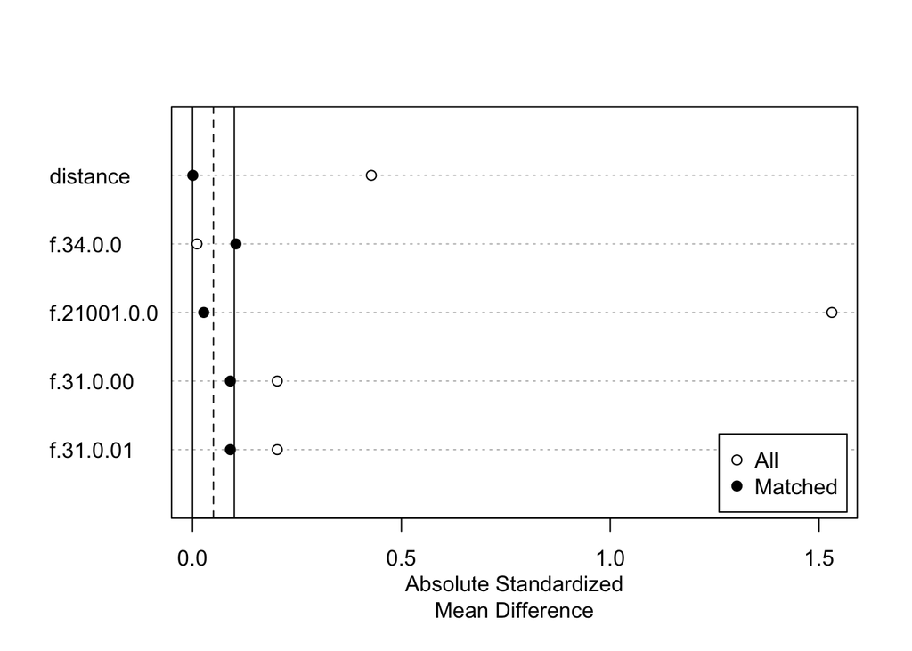

```r
matched=matchit(treat~f.34.0.0+f.21001.0.0+f.31.0.0,data=mg)
plot(summary(matched))
```

```r
datm=match.data(matched)
summary(matched)
```

```
##
## Call:
## matchit(formula = treat ~ f.34.0.0 + f.21001.0.0 + f.31.0.0,
##     data = mg)
##
## Summary of Balance for All Data:
##             Means Treated Means Control Std. Mean Diff. Var. Ratio eCDF Mean
## distance           0.0348        0.0046          0.4281    19.1574    0.3974
## f.34.0.0        1951.3251     1951.2476          0.0105     0.8504    0.0202
## f.21001.0.0       36.8923       27.5943          1.5306     1.5898    0.3620
## f.31.0.00          0.4454        0.5462         -0.2028          .    0.1008
## f.31.0.01          0.5546        0.4538          0.2028          .    0.1008
##             eCDF Max
## distance      0.6488
## f.34.0.0      0.0496
## f.21001.0.0   0.6689
## f.31.0.00     0.1008
## f.31.0.01     0.1008
##
## Summary of Balance for Matched Data:
##             Means Treated Means Control Std. Mean Diff. Var. Ratio eCDF Mean
## distance           0.0348        0.0348          0.0006     1.0085    0.0000
## f.34.0.0        1951.3251     1950.5602          0.1039     0.9444    0.0255
## f.21001.0.0       36.8923       36.7297          0.0268     0.9188    0.0132
## f.31.0.00          0.4454        0.4004          0.0905          .    0.0450
## f.31.0.01          0.5546        0.5996         -0.0905          .    0.0450
##             eCDF Max Std. Pair Dist.
## distance      0.0034          0.0010
## f.34.0.0      0.0720          1.0867
## f.21001.0.0   0.0394          0.2410
## f.31.0.00     0.0450          0.8781
## f.31.0.01     0.0450          0.8781
##
## Sample Sizes:
##           Control Treated
## All        186559     889
## Matched       889     889
## Unmatched  185670       0
## Discarded       0       0
```

Duration of treatment is the difference between last bmi and script date for treated and last bmi and enrollment for controls

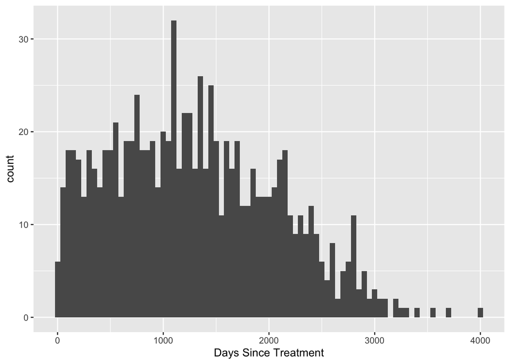

```r
ggplot(datm[datm$treat==1,],aes(as.numeric(diff)))+geom_histogram(binwidth = 50)+labs(x="Days Since Treatment")
```

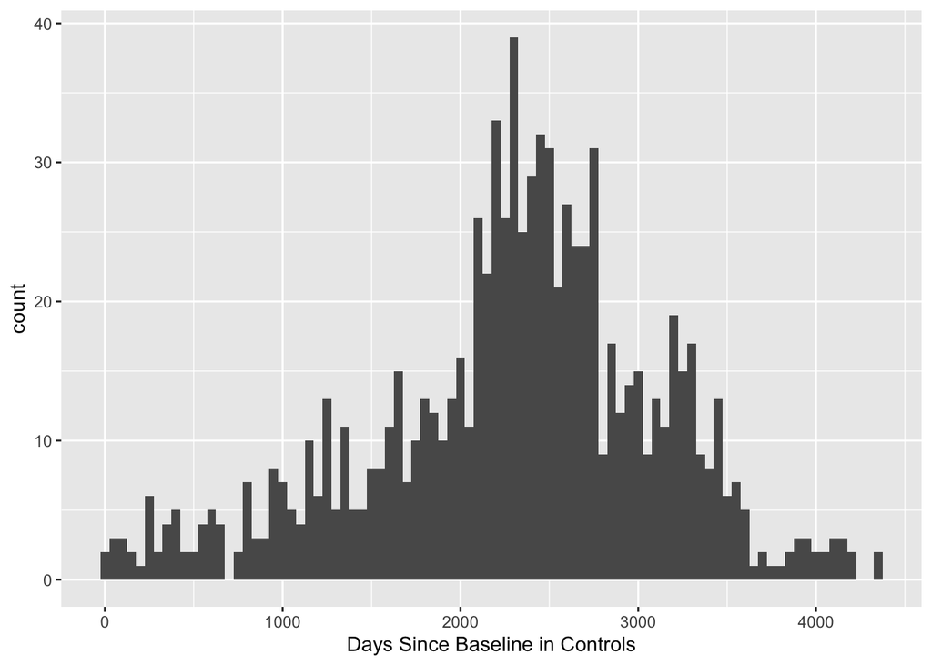

```r
ggplot(datm[datm$treat==0,],aes(as.numeric(diff)))+geom_histogram(binwidth = 50)+labs(x="Days Since Baseline in Controls")
```

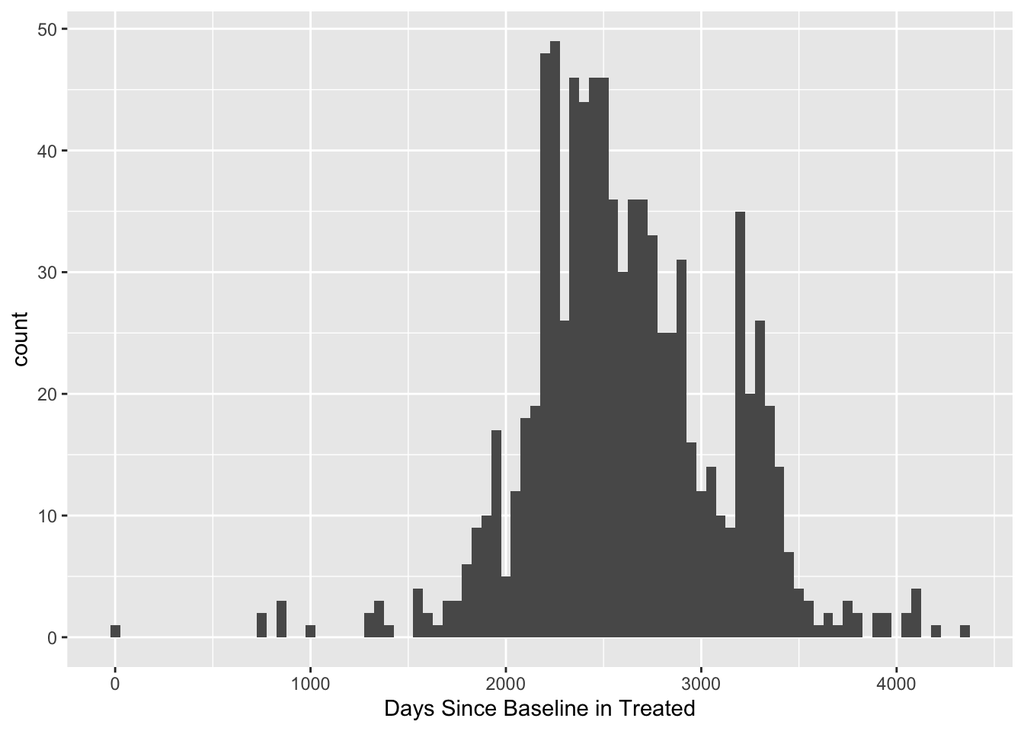

```r
datm$treatsincebase=difftime(datm[datm$treat==1,"date_last_bmi"],datm[datm$treat==1,"f.53.0.0"],units = "days")
ggplot(datm[datm$treat==1,],aes(as.numeric(treatsincebase)))+geom_histogram(binwidth = 50)+labs(x="Days Since Baseline in Treated")
```

Let’s look at change in BMI (not proportional)

```r
datm$delta=(datm$last_bmi-datm$f.21001.0.0)

your_model=lm(scale(delta)~treat+treat:bmi.prs,dat=datm,weights = weights)

summary(your_model)
```

```
##
## Call:
## lm(formula = scale(delta) ~ treat + treat:bmi.prs, data = datm,
##     weights = weights)
##
## Residuals:
##     Min      1Q  Median      3Q     Max
## -7.3969 -0.4990  0.0406  0.5891  4.9451
##
## Coefficients:
##               Estimate Std. Error t value Pr(>|t|)
## (Intercept)    0.07503    0.03342   2.245   0.0249 *
## treat         -0.10875    0.05131  -2.119   0.0342 *
## treat:bmi.prs -0.07285    0.03521  -2.069   0.0387 *
## ---
## Signif. codes:  0 '***' 0.001 '**' 0.01 '*' 0.05 '.' 0.1 ' ' 1
##
## Residual standard error: 0.9965 on 1775 degrees of freedom
## Multiple R-squared:  0.008026,   Adjusted R-squared:  0.006908
## F-statistic: 7.181 on 2 and 1775 DF,  p-value: 0.0007835
```

## just in treated

Now let’s examine the effect just in treated individuals

```r
your_model=lm(delta~bmi.prs,dat=datm[datm$treat==1,],weights = weights)
model_summary <- summary(your_model)
model_summary
```

```
##
## Call:
## lm(formula = delta ~ bmi.prs, data = datm[datm$treat == 1, ],
##     weights = weights)
##
## Residuals:
##     Min      1Q  Median      3Q     Max
## -27.646  -2.221   0.074   2.518  19.393
##
## Coefficients:
##             Estimate Std. Error t value Pr(>|t|)
## (Intercept)  -1.6103     0.1614  -9.977   <2e-16 ***
## bmi.prs      -0.2857     0.1460  -1.957   0.0506 .
## ---
## Signif. codes:  0 '***' 0.001 '**' 0.01 '*' 0.05 '.' 0.1 ' ' 1
##
## Residual standard error: 4.131 on 887 degrees of freedom
## Multiple R-squared:  0.0043, Adjusted R-squared:  0.003178
## F-statistic: 3.831 on 1 and 887 DF,  p-value: 0.05063
```

Now let’s look at some boxplots

- By treatment

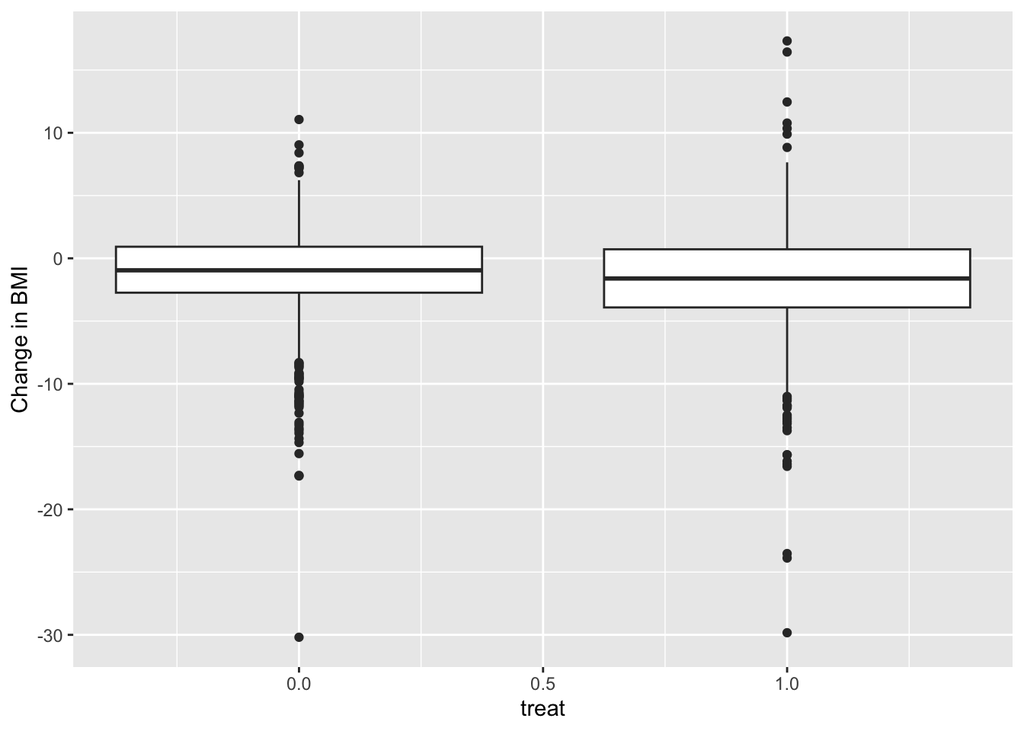

```r
p <- ggplot(datm, aes(x=treat, y=delta,group=treat)) +
  geom_boxplot()+labs(y="Change in BMI")

p
```

- By treatment and PRS decile

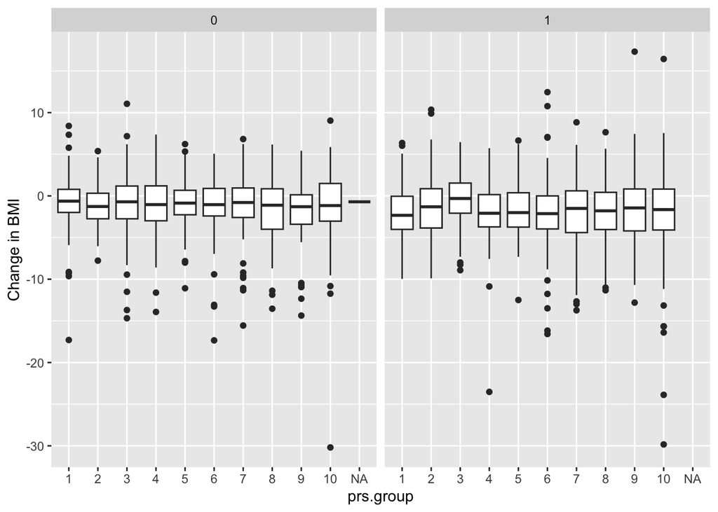

```r
datm$prs.group=cut(datm$bmi.prs,breaks = quantile(datm$bmi.prs,probs = seq(0,1,by=0.1)),labels = c(1:10))
p <- ggplot(datm, aes(x=prs.group, y=delta,group=prs.group)) +
  geom_boxplot()+labs(y="Change in BMI")+facet_wrap(~treat)

p
```

Now we repeat the analysis and restrict such that individuals must begin treatment *after enrollment*

```r
names(sorted_data)=c("eid","date_last_bmi","variable","source","last_bmi")
m2=m2[!is.na(m2$f.21001.0.0),]
mg=merge(m2,sorted_data,by.x="Identifier",by.y="eid")
mg$bmi.prs=mg$BMI

start_before_enroll=which(mg$treat==1&difftime(mg$script_date,mg$f.53.0.0)<0)
length(start_before_enroll==1)
```

```
## [1] 50
```

```r
## only 50
mg=mg[-start_before_enroll,]
```

```r
# length(which(difftime(mg$date_last_bmi,mg$f.53.0.0,units = "days")<0))
# w=which(difftime(mg$date_last_bmi,mg$f.53.0.0,units = "days")>0)
# length(w)
# mg=mg[w,]

mg$diff=ifelse(mg$treat==1,difftime(mg$date_last_bmi,time2=mg$script_date,units = "days"),difftime(mg$date_last_bmi,time2 = mg$f.53.0.0,units = "days"))
sum(mg$diff<0&mg$treat==1)
```

```
## [1] 52
```

```r
sum(mg$diff<0&mg$treat==0)
```

```
## [1] 35387
```

```r
mg=mg[mg$diff>0,]
```

Now complete the matching based on f.34 (birth year)

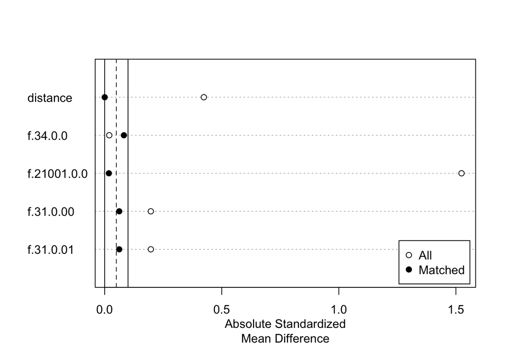

```r
matched=matchit(treat~f.34.0.0+f.21001.0.0+f.31.0.0,data=mg)
plot(summary(matched))
```

```r
datm=match.data(matched)
summary(matched)
```

```
##
## Call:
## matchit(formula = treat ~ f.34.0.0 + f.21001.0.0 + f.31.0.0,
##     data = mg)
##
## Summary of Balance for All Data:
##             Means Treated Means Control Std. Mean Diff. Var. Ratio eCDF Mean
## distance           0.0330        0.0043          0.4237    19.1479    0.3972
## f.34.0.0        1951.3933     1951.2476          0.0198     0.8536    0.0208
## f.21001.0.0       36.8931       27.5943          1.5242     1.6034    0.3616
## f.31.0.00          0.4482        0.5462         -0.1972          .    0.0981
## f.31.0.01          0.5518        0.4538          0.1972          .    0.0981
##             eCDF Max
## distance      0.6517
## f.34.0.0      0.0526
## f.21001.0.0   0.6686
## f.31.0.00     0.0981
## f.31.0.01     0.0981
##
## Summary of Balance for Matched Data:
##             Means Treated Means Control Std. Mean Diff. Var. Ratio eCDF Mean
## distance           0.0330        0.0330          0.0003     1.0043    0.0000
## f.34.0.0        1951.3933     1950.7867          0.0822     0.8950    0.0211
## f.21001.0.0       36.8931       36.7831          0.0180     0.8997    0.0124
## f.31.0.00          0.4482        0.4172          0.0623          .    0.0310
## f.31.0.01          0.5518        0.5828         -0.0623          .    0.0310
##             eCDF Max Std. Pair Dist.
## distance      0.0024          0.0008
## f.34.0.0      0.0560          1.0639
## f.21001.0.0   0.0369          0.2331
## f.31.0.00     0.0310          0.8820
## f.31.0.01     0.0310          0.8820
##
## Sample Sizes:
##           Control Treated
## All        186559     839
## Matched       839     839
## Unmatched  185720       0
## Discarded       0       0
```

Let’s look at change in BMI (not proportional)

```r
datm$delta=(datm$last_bmi-datm$f.21001.0.0)

your_model=lm(scale(delta)~treat+treat:bmi.prs,dat=datm,weights = weights)

summary(your_model)
```

```
##
## Call:
## lm(formula = scale(delta) ~ treat + treat:bmi.prs, data = datm,
##     weights = weights)
##
## Residuals:
##     Min      1Q  Median      3Q     Max
## -7.0342 -0.5087  0.0410  0.5579  4.9471
##
## Coefficients:
##               Estimate Std. Error t value Pr(>|t|)
## (Intercept)    0.08936    0.03437   2.600  0.00942 **
## treat         -0.14171    0.05282  -2.683  0.00737 **
## treat:bmi.prs -0.06576    0.03672  -1.791  0.07351 .
## ---
## Signif. codes:  0 '***' 0.001 '**' 0.01 '*' 0.05 '.' 0.1 ' ' 1
##
## Residual standard error: 0.9956 on 1675 degrees of freedom
## Multiple R-squared:  0.009885,   Adjusted R-squared:  0.008703
## F-statistic: 8.361 on 2 and 1675 DF,  p-value: 0.0002436
```

## just in treated

Now let’s examine the effect just in treated individuals

```r
your_model=lm(delta~bmi.prs,dat=datm[datm$treat==1,],weights = weights)
model_summary <- summary(your_model)
model_summary
```

```
##
## Call:
## lm(formula = delta ~ bmi.prs, data = datm[datm$treat == 1, ],
##     weights = weights)
##
## Residuals:
##      Min       1Q   Median       3Q      Max
## -27.6227  -2.1684   0.0832   2.4362  19.4266
##
## Coefficients:
##             Estimate Std. Error t value Pr(>|t|)
## (Intercept)  -1.6887     0.1648 -10.246   <2e-16 ***
## bmi.prs      -0.2582     0.1509  -1.711   0.0874 .
## ---
## Signif. codes:  0 '***' 0.001 '**' 0.01 '*' 0.05 '.' 0.1 ' ' 1
##
## Residual standard error: 4.092 on 837 degrees of freedom
## Multiple R-squared:  0.003486,   Adjusted R-squared:  0.002296
## F-statistic: 2.928 on 1 and 837 DF,  p-value: 0.08741
```

Now let’s look at some boxplots

- By treatment

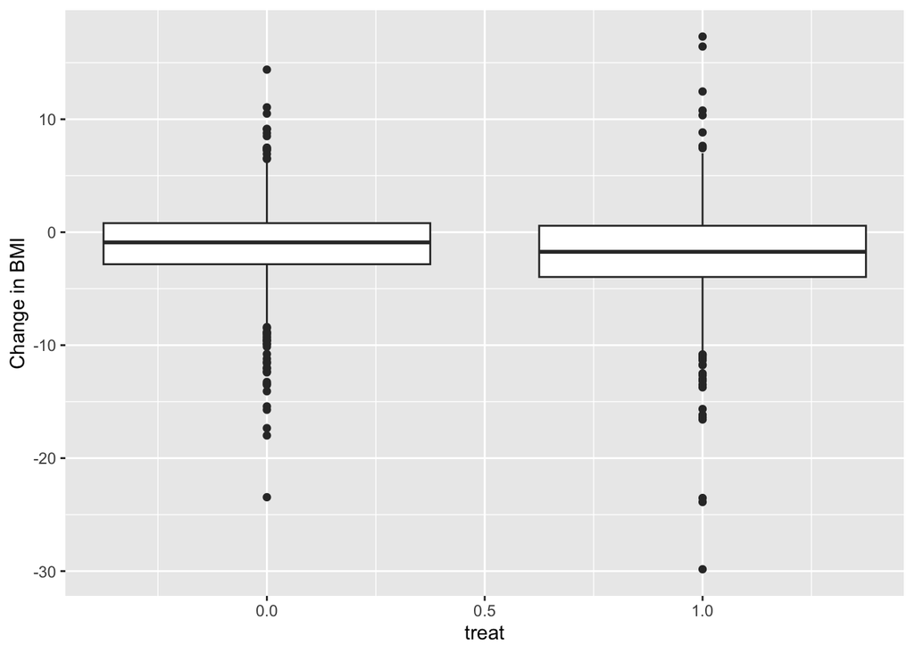

```r
p <- ggplot(datm, aes(x=treat, y=delta,group=treat)) +
  geom_boxplot()+labs(y="Change in BMI")

p
```

- By treatment and PRS decile

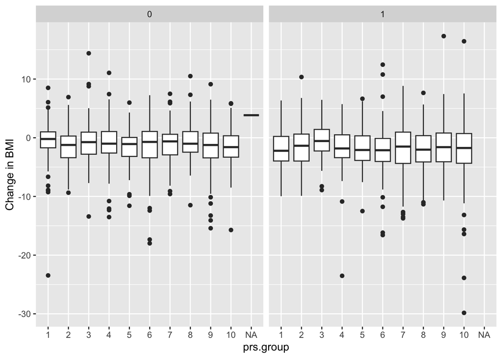

```r
datm$prs.group=cut(datm$bmi.prs,breaks = quantile(datm$bmi.prs,probs = seq(0,1,by=0.1)),labels = c(1:10))
p <- ggplot(datm, aes(x=prs.group, y=delta,group=prs.group)) +
  geom_boxplot()+labs(y="Change in BMI")+facet_wrap(~treat)

p
```